# COVID-19 Worldwide: Trends, Demographics, and Economic Context

### Inflation rate vs. Reproduction rate by continent

```r
#Visualisation of Inflation Rate vs Reproduction rate by continent over time
fig5 <- merged.data.visualisation %>%
  plot_ly(
    x = ~ inflation_rate,
    y = ~ reproduction_rate,
    color = ~ continent,
    frame = ~ year,
    #Year slider to move through 2020-2023
    #Scatter plots with markers
    type = "scatter",
    mode = "markers",
    marker = list(size = 12, opacity = 0.7),
    #Custom hover text to display key information interactively
    text = ~ paste(
      "Continent:",
      continent,
      "<br>",
      "Year:",
      year,
      "<br>",
      "Inflation rate:",
      round(inflation_rate, 2),
      "%<br>",
      "Reproduction rate:",
      round(reproduction_rate, 2)
    ),
    hoverinfo = "text"
  ) %>%
  layout(
    title = "Inflation rate vs Reproduction rate by continent (2020–2023)",
    xaxis = list(title = "Inflation rate"),
    yaxis = list(title = "Reproduction rate"),
    #Place legend outside the plot area for readability
    legend = list(
      x = 1.05,
      xanchor = "left",
      y = 0.5,
      yanchor = "middle"
    ),
    margin = list(r = 150)
  )

#Display scatter plot
fig5
```

[interactive chart not shown]

In 2020 and 2021, most continents had relatively stable reproduction rates around or slightly above 1, while inflation varied widely, with Africa showing especially high levels. By 2022, reproduction rates began to fall below 1 overall, while inflation rose across continents. In 2023, reproduction rates dropped further, but inflation decreased slightly, still showing the economic pressure during the pandemic years.

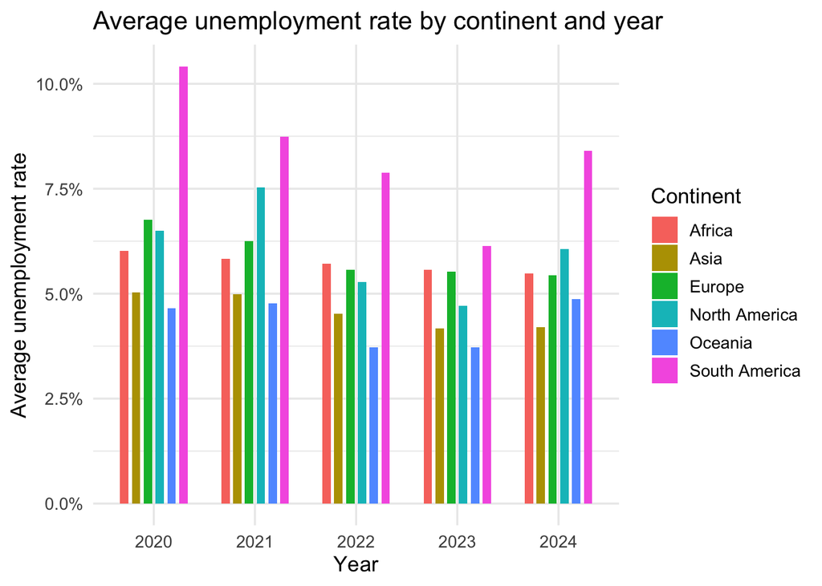

```r
#Visualisation of Average unemployment rate over the years by continent
ggplot(merged.data,
       aes(x = factor(year), y = unemployment_rate, fill = continent)) +
  stat_summary(
    fun = median, #Median per group
    geom = "col",
    position = position_dodge(width = 0.7),
    width = 0.5,
    na.rm = TRUE
  ) +
  scale_y_continuous(labels = label_percent(scale = 1)) +
  labs(title = "Average unemployment rate by continent and year",
       x = "Year",
       y = "Average unemployment rate",
       fill = "Continent") +
  theme_minimal(base_size = 13)
```

Overall, unemployment rates declined somewhat from 2020 to 2023 before rising again slightly in 2024. The chart highlights persistent regional differences, with South America facing the greatest labor market challenges. South Americas unemployment peak in 2020 reflects the immediate shock of the pandemic, while the decline in subsequent years shows the effect of the recovery. Comparatively, Africa, Oceania, Europe, Asia and North America experienced more stable and comparatively lower unemployment. Importantly, these labor market trends mirror the timing of COVID-19 waves and vaccination rollouts, showing how the pandemic not only affected health outcomes but also had lasting economic consequences across regions.

## Fitting model

After producing descriptive visualisations, we wanted to move beyond simple plots and test whether there was a measurable relationship between a country’s economic status and its reported COVID-19 burden. Specifically, we asked:

> *Do countries with higher GDP per capita tend to report more total COVID-19 cases?*

To address this, we fitted a simple linear regression model using our merged dataset, with total cases as the dependent variable and GDP per capita as the explanatory variable. Before fitting the model, we removed rows with missing values in either variable to ensure the results were based only on valid observations. Because both GDP and case counts vary by several orders of magnitude across countries, we applied transformations (scaling) to make the relationship easier to model and interpret. We then examined the regression summary and diagnostic plots to assess the strength and form of the relationship.

```
##
## Call:
## lm(formula = scale(total_cases) ~ scale(GDP), data = merged.data.lm)
##
## Residuals:
##     Min      1Q  Median      3Q     Max
## -1.1082 -0.2171 -0.1824 -0.1259 12.7653
##
## Coefficients:
##              Estimate Std. Error t value Pr(>|t|)
## (Intercept) 1.526e-14  2.447e-03    0.00        1
## scale(GDP)  1.122e-01  2.447e-03   45.84   <2e-16 ***
## ---
## Signif. codes:  0 '***' 0.001 '**' 0.01 '*' 0.05 '.' 0.1 ' ' 1
##
## Residual standard error: 0.9937 on 164893 degrees of freedom
## Multiple R-squared:  0.01258,    Adjusted R-squared:  0.01258
## F-statistic:  2101 on 1 and 164893 DF,  p-value: < 2.2e-16
```

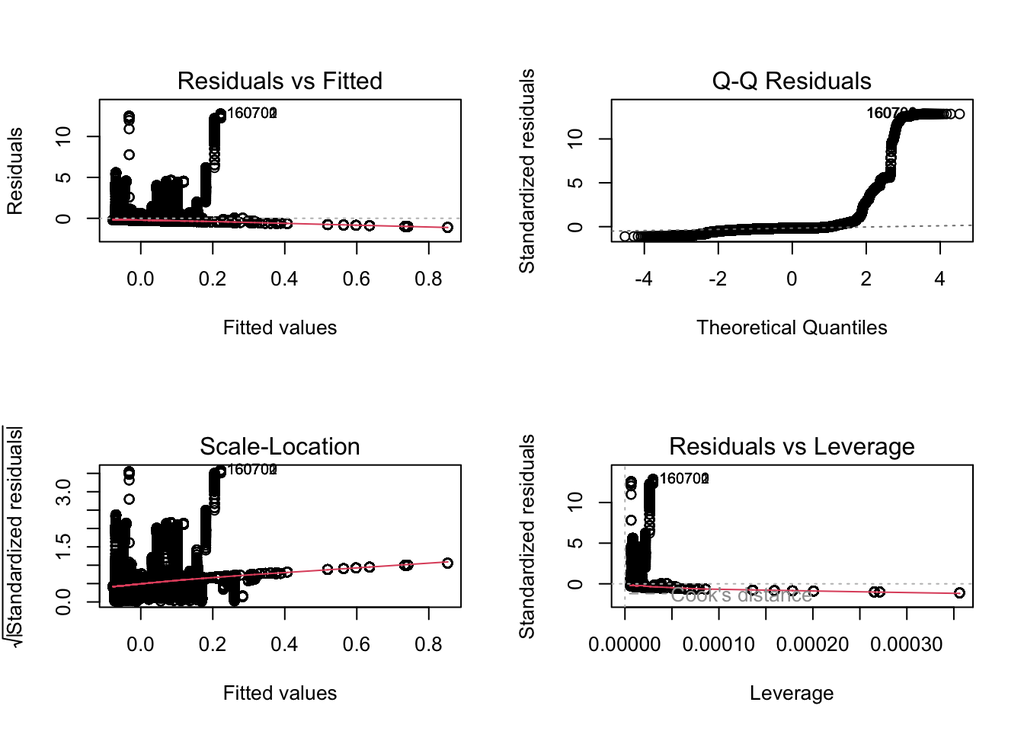

The linear regression model examined the relationship between GDP per capita and total COVID-19 cases across countries. The results showed a *statistically significant positive association*, with higher-GDP countries tending to report more cases. Specifically, for every one standard deviation increase in GDP, reported cases increased by about **0.11** standard deviations on average. However, the explanatory power of the model was very low, with an R-squared value of only **1.3%**, indicating that GDP alone explains very little of the variation in case numbers.

The diagnostic plots further revealed violations of model assumptions: residuals were not normally distributed, heteroscedasticity was present (increasing variance with fitted values), and a small number of influential outliers appeared to dominate the fit. These issues likely arise because absolute totals for both GDP and cases are strongly influenced by population size and because the data are highly skewed. Taken together, the results suggest that while GDP is positively associated with reported cases, it is a weak predictor on its own.

## Chapter of choice

The animation allows users to observe how GDP per capita evolved over time, while the interactive slider makes it possible to explore individual years in detail. By hovering over a country, one can view its name, year, and GDP per capita value. In addition, zooming in and out of the map is possible. The resulting map highlights both the persistent disparities in GDP levels between low, middle, and high-income countries and the relative pace of economic change across regions.

```r
gdp_map_data <- world.indicator.selected %>%
  #Keep only years of interest (2020 - 2024)
  filter(year %in% 2020:2024) %>%

  #Convert country names to IS03 codes
  mutate(iso3 = countrycode(location, "country.name", "iso3c")) %>%
  group_by(iso3, location, year) %>%

  #Summarise GDP per country-year level using median
  summarise(median_gdp = median(GDP, na.rm = TRUE), .groups = "drop") %>%

  #Remove invalid rows: missing ISO3, infinite values or non positive GDP
  filter(!is.na(iso3), is.finite(median_gdp), median_gdp > 0) %>%

  #Apply Log10 transform for better contrast and comparability
  mutate(log_gdp = log10(median_gdp))


#Defining color bar ticks
ticks_real <- c(2000, 5000, 10000, 20000, 50000, 100000)


#Visualising choropleth Animated Map with slider for each year
fig6 <- plot_ly(
  data = gdp_map_data,
  type = "choropleth",

  #Map countries using ISO3
  locations = ~ iso3,
  locationmode = "ISO-3",

  #Colourshading based on log-transformed GDP
  z = ~ log_gdp,

  #Show slider across years
  frame = ~ year,

  #Choose a sequential blue-green colour scale
  colorscale = "YlGnBu",

  #Customise color bar
  colorbar = list(
    title = "GDP per capita (USD)",
    tickvals = log10(ticks_real),
    ticktext = comma(ticks_real)
  ),
  #Show tooltip text on hover
  text = ~ paste0(
    "Country: ",
    location,
    "<br>Year: ",
    year,
    "<br>GDP per capita: $",
    comma(median_gdp)
  ),
  hoverinfo = "text"  #Show tool tip with above text
) %>%
  layout(
    title = "GDP per capita by country (2020–2025)",
    geo = list(
      showframe = FALSE,
      showcoastlines = TRUE,
      projection = list(type = "equirectangular")
    )
  ) %>%

  #Animation speed and transition style
  animation_opts(1000, easing = "linear") %>%

  #Add slider to interactively pick a year
  animation_slider(currentvalue = list(prefix = "Year: "))

#Display the animated map
fig6
```

[interactive chart not shown]

From 2020 to 2023, the map illustrates the uneven recovery from the pandemic. Wealthier countries, for example the United States or countries in Western Europe largely sustained or regained high GDP per capita levels, while many developing economies such as countries in Africa, in the Middle East or in South America saw only modest improvements, leaving global disparities very visible. At the same time, the persistence of low-income regions underlines the long-term challenges of achieving a more balanced global development.

## Summary

In summary, our analysis combined COVID-19 health data with socio-economic indicators from the World Bank to explore how different regions experienced the pandemic. We found clear patterns in case fatality rates and unemployment, with South America standing out for particularly high labor market disruption. Wealthier countries showed stronger economic resilience, but correlations between socio-economic indicators and pandemic outcomes were generally weak, highlighting the complexity of the crisis. The findings indicate that global crisis are multi-dimensional, where health, economy and social systems interact in complex ways, making it difficult to make one-to-one interpretations. Overall, the results underline that while economic context matters, health outcomes during COVID-19 were shaped by a wide range of unknown factors, which cannot be fully determined in this report.

## Take Home

Through this project, we learnt how to prepare large, complex datasets for analysis, including handling missing values, converting data types, aggregating data at different levels, producing various visualisations (both static and interactive), modelling data and performing log transformations to deal with skewed distributions. We also gained hands on experience in integrating datasets from different domains (health and economics). Although it was a complex and large dataset to work with, this project also reinforced the value of interdisciplinary approaches, showing that socio-economic and health outcomes cannot be fully explained by single variables.

## Limitations

The project also revealed several challenges such as the complexity of the data with different time resolutions, varying levels of completeness across regions and substantial skewness in variables like cases, deaths and GDP. We encountered so many missing and invalid entries, for example, the absence of valid data for the year 2024 during visualisation, which limited the scope of some analysis. Moreover, absolute totals were often dominated by population size, requiring careful interpretation. Other limitations include inconsistencies in how countries reported their COVID-19 cases and deaths, underreporting in low-resource countries. While log-transformation improved comparability and readability, it may have also masked absolute differences. Finally, the associations identified cannot be identified as strong or causal, since multiple confounding factors may have had an impact on the results.

## Comment on the use of Generative AI

We used AI, mainly ChatGPT, to support idea finding in the beginning, data preparation, straighten out R coding, polish the written report and help with certain wording and expressing thoughts. In addition, the use of generative AI helped us in some sense on how to find solutions when problems arose. This allowed us to save time on repetitive technical tasks and focus more on critical interpretation and drawing meaningful insights. At the same time, we remained cautious to validate all outputs, ensuring that the analysis and conclusions reflect our own understanding and ideas.